# Simple Linear Regression

```r
library(tidyverse)

project_management <- read_csv("data/project_management.csv")
```

estimated_length - contains the estimated length of a building job in days actual_length - contains the actual recorded length of the job in days

We are interested in determining the accuracy of the job estimations made by the company using simple linear regression,

actual_length as the dependent variable - y estimated_length as the independent variable - x

1. Plot the data, taking estimated_length as the independent variable and actual_length as the dependent variable.

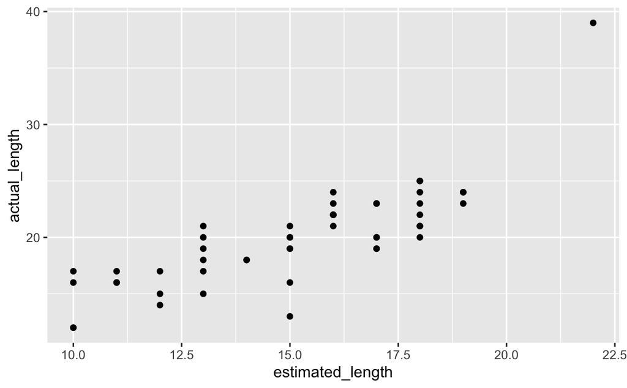

```r
project_management %>%
  ggplot(aes(x = estimated_length, y = actual_length))+
  geom_point()
```

2. Calculate the correlation coefficient of estimated_length and actual_length and interpret the value you obtain.

```r
project_management %>%
  summarise(cor(estimated_length, actual_length))
```

| cor(estimated_length, actual_length) |
| --- |
| 0.8046597 |

Correlation coefficient is very strong. They are positively correlated.

3. Perform a simple linear regression using actual_length as the dependent variable, and estimated_length as the independent variable. Save the model object to a variable.

```r
# y ~ x
model <- lm(formula = actual_length ~ estimated_length, data = project_management)

model
```

[output not shown]

```r
library(broom)
glance(model)
```

| r.squared | adj.r.squared | sigma | statistic | p.value | df | logLik | AIC | BIC | deviance | df.residual | nobs |
| --- | --- | --- | --- | --- | --- | --- | --- | --- | --- | --- | --- |
| 0.6474772 | 0.640133 | 2.606163 | 88.16142 | 1.911284e-12 | 1 | -117.8203 | 241.6407 | 247.3767 | 326.0201 | 48 | 50 |

4. Interpret the regression coefficient of estimated_length (i.e. slope, gradient) you obtain from the model. How do you interpret the r2 value reported by the model?

```
`arrange_()` is deprecated as of dplyr 0.7.0.
Please use `arrange()` instead.
See vignette('programming') for more help
```

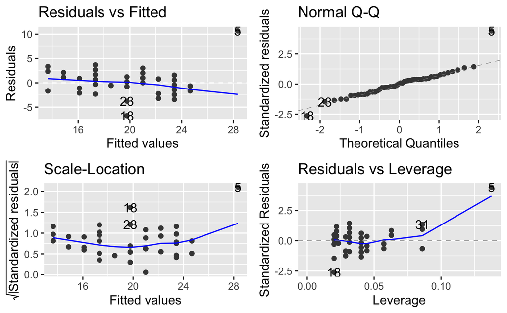

```r
library(ggfortify)
autoplot(model)
```

5. Is the relationship statistically significant? Remember, to assess this you need to check the p-value of the regression coefficient (or slope/gradient). But you should first check the regression diagnostic plots to see if the p-value will be reliable (don’t worry about any outlier points you see in the diagnostic plots, we’ll return to them in the extension).